# Project Python Foundations: FoodHub Data Analysis

**Marks: 60**

### Context

The number of restaurants in New York is increasing day by day. Lots of students and busy professionals rely on those restaurants due to their hectic lifestyles. Online food delivery service is a great option for them. It provides them with good food from their favorite restaurants. A food aggregator company FoodHub offers access to multiple restaurants through a single smartphone app.

The app allows the restaurants to receive a direct online order from a customer. The app assigns a delivery person from the company to pick up the order after it is confirmed by the restaurant. The delivery person then uses the map to reach the restaurant and waits for the food package. Once the food package is handed over to the delivery person, he/she confirms the pick-up in the app and travels to the customer's location to deliver the food. The delivery person confirms the drop-off in the app after delivering the food package to the customer. The customer can rate the order in the app. The food aggregator earns money by collecting a fixed margin of the delivery order from the restaurants.

### Objective

The food aggregator company has stored the data of the different orders made by the registered customers in their online portal. They want to analyze the data to get a fair idea about the demand of different restaurants which will help them in enhancing their customer experience. Suppose you are hired as a Data Scientist in this company and the Data Science team has shared some of the key questions that need to be answered. Perform the data analysis to find answers to these questions that will help the company to improve the business.

### Data Description

The data contains the different data related to a food order. The detailed data dictionary is given below.

### Data Dictionary

- order_id: Unique ID of the order
- customer_id: ID of the customer who ordered the food
- restaurant_name: Name of the restaurant
- cuisine_type: Cuisine ordered by the customer
- cost: Cost of the order
- day_of_the_week: Indicates whether the order is placed on a weekday or weekend (The weekday is from Monday to Friday and the weekend is Saturday and Sunday)
- rating: Rating given by the customer out of 5
- food_preparation_time: Time (in minutes) taken by the restaurant to prepare the food. This is calculated by taking the difference between the timestamps of the restaurant's order confirmation and the delivery person's pick-up confirmation.
- delivery_time: Time (in minutes) taken by the delivery person to deliver the food package. This is calculated by taking the difference between the timestamps of the delivery person's pick-up confirmation and drop-off information

### Let us start by importing the required libraries

```python
# import libraries for data manipulation
import numpy as np
import pandas as pd

# import libraries for data visualization
import matplotlib.pyplot as plt
import seaborn as sns

# to restrict the float value to 3 decimal places
pd.set_option('display.float_format', lambda x: '%.3f' % x)
```

### Understanding the structure of the data

```python
# This code mounts the google drive so we can read in the CSV file
from google.colab import drive
drive.mount('/content/drive')
```

```python
# read the data
fd_data = pd.read_csv('/content/drive/My Drive/DSBA/Project 1/foodhub_order.csv')
# returns the first 5 rows
fd_data.head()
```

|  | order_id | customer_id | restaurant_name | cuisine_type | cost_of_the_order | day_of_the_week | rating | food_preparation_time | delivery_time |
| --- | --- | --- | --- | --- | --- | --- | --- | --- | --- |
| 0 | 1477147 | 337525 | Hangawi | Korean | 30.750 | Weekend | Not given | 25 | 20 |
| 1 | 1477685 | 358141 | Blue Ribbon Sushi Izakaya | Japanese | 12.080 | Weekend | Not given | 25 | 23 |
| 2 | 1477070 | 66393 | Cafe Habana | Mexican | 12.230 | Weekday | 5 | 23 | 28 |
| 3 | 1477334 | 106968 | Blue Ribbon Fried Chicken | American | 29.200 | Weekend | 3 | 25 | 15 |
| 4 | 1478249 | 76942 | Dirty Bird to Go | American | 11.590 | Weekday | 4 | 25 | 24 |

#### Observations:

The DataFrame has 9 columns as mentioned in the Data Dictionary. Data in each row corresponds to the order placed by a customer.

### **Question 1:** How many rows and columns are present in the data? [0.5 mark]

```python
print("There are", fd_data.shape[0], 'rows and', fd_data.shape[1], "columns.")
```

```
There are 1898 rows and 9 columns.
```

#### Observations: There are 1898 rows and 9 columns in the data

### **Question 2:** What are the datatypes of the different columns in the dataset? (The info() function can be used) [0.5 mark]

```python
# Use info() to print a concise summary of the DataFrame
fd_data.info()
```

```
<class 'pandas.core.frame.DataFrame'>
RangeIndex: 1898 entries, 0 to 1897
Data columns (total 9 columns):
 #   Column                 Non-Null Count  Dtype
---  ------                 --------------  -----
 0   order_id               1898 non-null   int64
 1   customer_id            1898 non-null   int64
 2   restaurant_name        1898 non-null   object
 3   cuisine_type           1898 non-null   object
 4   cost_of_the_order      1898 non-null   float64
 5   day_of_the_week        1898 non-null   object
 6   rating                 1898 non-null   object
 7   food_preparation_time  1898 non-null   int64
 8   delivery_time          1898 non-null   int64
dtypes: float64(1), int64(4), object(4)
memory usage: 133.6+ KB
```

#### Observations: There are 9 collumns present in the dataframe with 4 object columns represented by categorical variables and 5 numerical columns represented by floats and integer values

### **Question 3:** Are there any missing values in the data? If yes, treat them using an appropriate method. [1 mark]

```python
pd.DataFrame({'Count':fd_data.isnull().sum()[fd_data.isnull().sum()>0],'Percentage':(fd_data.isnull().sum()[fd_data.isnull().sum()>0]/fd_data.shape[0])*100})
```

|  | Count | Percentage |
| --- | --- | --- |

#### Observations: There are no missing values in the data

### **Question 4:** Check the statistical summary of the data. What is the minimum, average, and maximum time it takes for food to be prepared once an order is placed? [2 marks]

```python
print('This is the Statistical Summary of the Data')
fd_data.describe()
```

```
This is the Statistical Summary of the Data
```

|  | order_id | customer_id | cost_of_the_order | food_preparation_time | delivery_time |
| --- | --- | --- | --- | --- | --- |
| count | 1898.000 | 1898.000 | 1898.000 | 1898.000 | 1898.000 |
| mean | 1477495.500 | 171168.478 | 16.499 | 27.372 | 24.162 |
| std | 548.050 | 113698.140 | 7.484 | 4.632 | 4.973 |
| min | 1476547.000 | 1311.000 | 4.470 | 20.000 | 15.000 |
| 25% | 1477021.250 | 77787.750 | 12.080 | 23.000 | 20.000 |
| 50% | 1477495.500 | 128600.000 | 14.140 | 27.000 | 25.000 |
| 75% | 1477969.750 | 270525.000 | 22.297 | 31.000 | 28.000 |
| max | 1478444.000 | 405334.000 | 35.410 | 35.000 | 33.000 |

```python
print('Minimum Preparation Time =', fd_data['food_preparation_time'].min(),'mins')
print('Average Preparation Time =', fd_data['food_preparation_time'].mean(),'mins')
print('Max Preparation Time =', fd_data['food_preparation_time'].max(),'mins')
```

```
Minimum Preparation Time = 20 mins
Average Preparation Time = 27.371970495258168 mins
Max Preparation Time = 35 mins
```

#### Observations: The statistical summary of the data cuts across 5 integer or float columns. The 'Rating'column is considered as an object and as such is not defined here

### **Question 5:** How many orders are not rated? [1 mark]

```python
fd_data['rating'].unique()
```

```
array(['Not given', '5', '3', '4'], dtype=object)
```

```python
print('There are', fd_data['rating'].value_counts()['Not given'],'orders not rated')
```

```
There are 736 orders not rated
```

#### Observations: Though there are no missing values under the rating column, 736 orders have not been rated which could be considered missing in some terms

### Exploratory Data Analysis (EDA)

### **Question 6:** Explore all the variables and provide observations on their distributions. (Generally, histograms, boxplots, countplots, etc. are used for univariate exploration.) [9 marks]

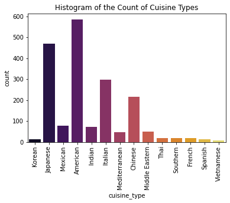

```python
sns.countplot(data=fd_data,x='cuisine_type',palette='inferno')
plt.xticks(rotation=90)
plt.title('Histogram of the Count of Cuisine Types')
plt.show()
```

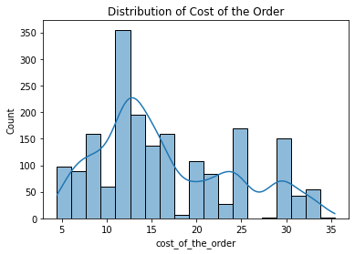

```python
sns.histplot(data=fd_data, x='cost_of_the_order', kde=True);
plt.title('Distribution of Cost of the Order')
```

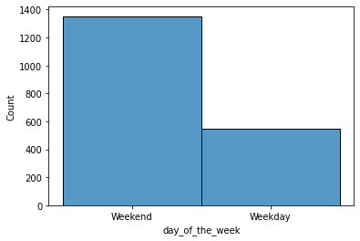

```python
sns.histplot(data=fd_data, x='day_of_the_week');
```

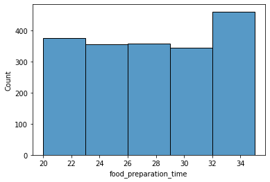

```python
sns.histplot(data=fd_data, x='food_preparation_time', bins=5);
```

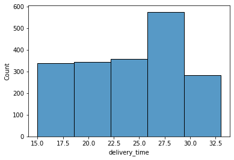

```python
sns.histplot(data=fd_data, x='delivery_time', bins=5);
```

### **Question 7**: Which are the top 5 restaurants in terms of the number of orders received? [1 mark]

```python
fd_data['restaurant_name'].unique()
fd_data['restaurant_name'].value_counts()
```

```
Shake Shack                  219
The Meatball Shop            132
Blue Ribbon Sushi            119
Blue Ribbon Fried Chicken     96
Parm                          68
                            ...
Sushi Choshi                   1
Dos Caminos Soho               1
La Follia                      1
Philippe Chow                  1
'wichcraft                     1
Name: restaurant_name, Length: 178, dtype: int64
```

#### Observations: The top 5 Restaurants in terms of number of orders received are

- Shake Shack
- The Meatball Shop
- Blue Ribbon Sushi
- Blue Ribbon Fried Chicken
- Parm

### **Question 8**: Which is the most popular cuisine on weekends? [1 mark]

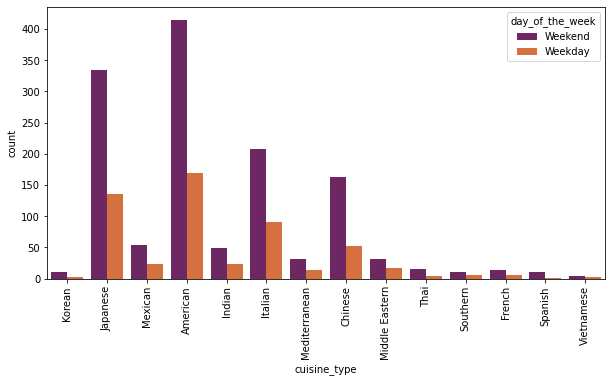

```
The most popular cuisine on the weekends going by the Countplot below is American
```

```python
plt.figure(figsize=(10,5))
sns.countplot(data=fd_data, x='cuisine_type', hue='day_of_the_week', palette='inferno')
plt.xticks(rotation=90)
plt.show()
print('The most popular cuisine on the weekends going by the Countplot below is American')
```

#### Observations:

The most popular cuisine on the weekends going by the Countplot below is American

### **Question 9**: What percentage of the orders cost more than 20 dollars? [2 marks]

```python
#fd_data['Cost_Type'] = fd_data['food_preparation_time'] + fd_data['delivery_time']
def costing(i):
  if i>20:
    return 'Over $20'
  elif 0<i<20:
    return'Under $20'
  else:
    'N/A'
fd_data['Cost_type'] = fd_data['cost_of_the_order'].apply(costing)
fd_data.head()
```

[output not shown]

```python
fd_data['Cost_type'].value_counts(normalize=True)
```

```
Under $20   0.708
Over $20    0.292
Name: Cost_type, dtype: float64
```

#### Observations: The percentage of orders over $20 is 29.2% or 555 orders

### **Question 10**: What is the mean order delivery time? [1 mark]

```python
print('Mean Order Delivery Time =', fd_data['delivery_time'].mean(),'mins')
```

```
Mean Order Delivery Time = 24.161749209694417 mins
```

#### Observations: The mean order delivery time is 24.16mins

### **Question 11:** The company has decided to give 20% discount vouchers to the top 3 most frequent customers. Find the IDs of these customers and the number of orders they placed. [1 mark]

```python
fd_data['customer_id'].unique()
fd_data['customer_id'].value_counts().head(3)
```

```
52832    13
47440    10
83287     9
Name: customer_id, dtype: int64
```

#### Observations: The top 3 customers as highlighted above are

- Customer_id 52832 - 13 orders
- Customer_id 47440 - 10 orders
- Customer_id 83287 - 9 orders

### **Question 12**: Perform a multivariate analysis to explore relationships between the important variables in the dataset. (It is a good idea to explore relations between numerical variables as well as relations between numerical and categorical variables) [10 marks]

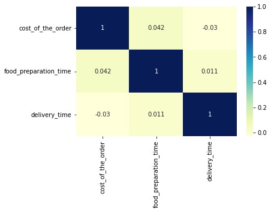

```python
sns.heatmap(data=fd_data[['cost_of_the_order','rating','food_preparation_time','delivery_time']].corr(), annot=True, cmap='YlGnBu');
```

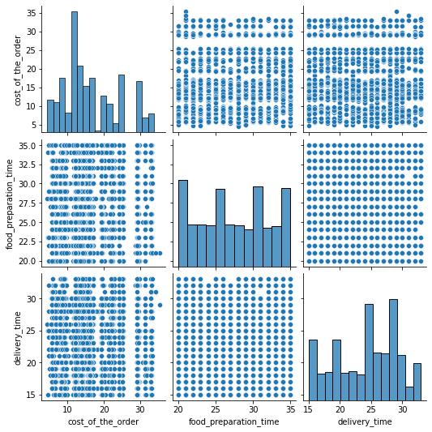

```python
sns.pairplot(data=fd_data[['cost_of_the_order','food_preparation_time','delivery_time']]);
```

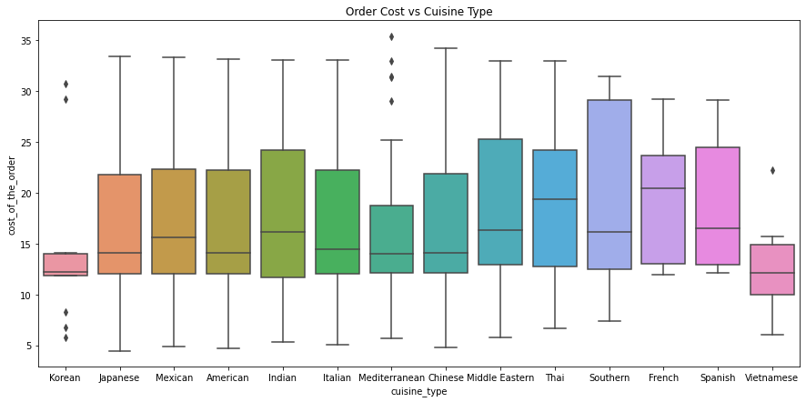

```python
plt.figure(figsize=(15,7))
sns.boxplot(data=fd_data, x='cuisine_type', y='cost_of_the_order');
plt.title('Order Cost vs Cuisine Type')
```

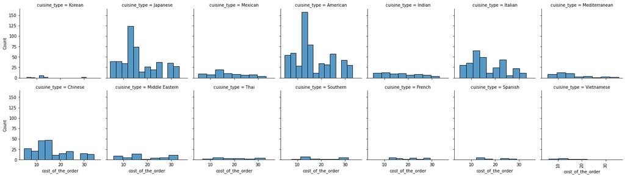

```python
plt.figure(figsize=(15,5))
g = sns.FacetGrid(data=fd_data, col="cuisine_type", col_wrap=7)
g.map(sns.histplot, "cost_of_the_order");
plt.xticks(rotation=90)
plt.show()
```

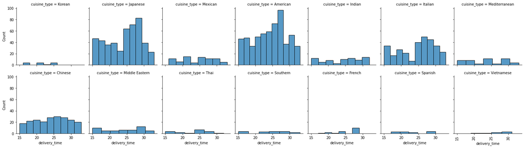

```python
plt.figure(figsize=(15,5))
g = sns.FacetGrid(data=fd_data, col="cuisine_type", col_wrap=7)
g.map(sns.histplot, "delivery_time");
plt.xticks(rotation=90)
plt.show()
```

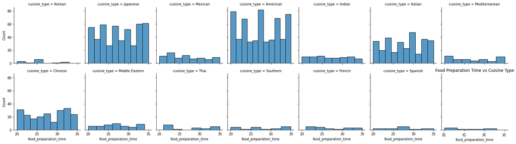

```python
plt.figure(figsize=(15,5))
g = sns.FacetGrid(data=fd_data, col="cuisine_type", col_wrap=7)
g.map(sns.histplot, "food_preparation_time");
plt.title('Food Preparation Time vs Cuisine Type')
plt.xticks(rotation=90)
plt.show()
```

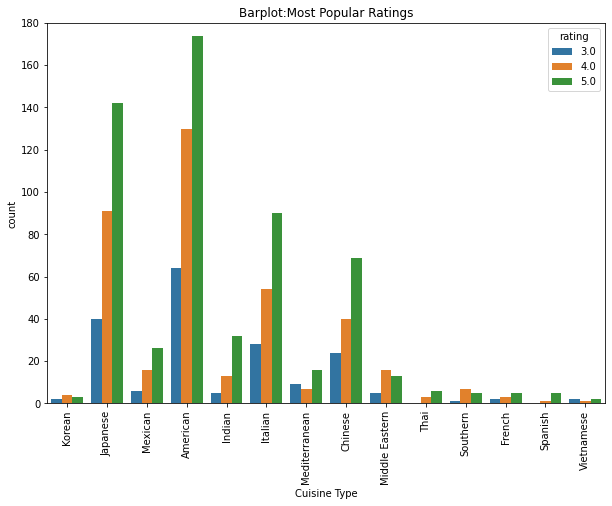

```python
plt.figure(figsize=(10,7))
plt.title('Barplot:Most Popular Ratings')
plt.ylim(0,180)
sns.countplot(data=fd_data, x='cuisine_type',hue='rating')
plt.xticks(rotation=90)
plt.xlabel('Cuisine Type');
```

### **Question 13:** The company wants to provide a promotional offer in the advertisement of the restaurants. The condition to get the offer is that the restaurants must have a rating count of more than 50 and the average rating should be greater than 4. Find the restaurants fulfilling the criteria to get the promotional offer. [3 marks]

```python
fd_data['rating'] = fd_data['rating'].replace(['Not given'],np.nan)
fd_data['rating'] = fd_data['rating'].astype(float)
fd_data_rating = fd_data.groupby(['restaurant_name'])['rating'].mean()
fd_data_rating
```

```
restaurant_name
'wichcraft         5.000
12 Chairs          4.500
5 Napkin Burger    4.000
67 Burger          5.000
Alidoro              NaN
                    ...
Zero Otto Nove     4.000
brgr               3.000
da Umberto         5.000
ilili Restaurant   4.154
indikitch          4.500
Name: rating, Length: 178, dtype: float64
```

```python
print('The Mean of Shake Shack orders is equal to', fd_data_rating['Shake Shack'])
print('The Mean of The Meatball Shop orders is equal to', fd_data_rating['The Meatball Shop'])
print('The Mean of Blue Ribbon Sushi orders is equal to', fd_data_rating['Blue Ribbon Sushi'])
print('The Mean of Blue Ribbon Fried Chicken orders is equal to', fd_data_rating['Blue Ribbon Fried Chicken'])
print('The Mean of Parm orders is equal to', fd_data_rating['Parm'])
```

```
The Mean of Shake Shack orders is equal to 4.2781954887218046
The Mean of The Meatball Shop orders is equal to 4.511904761904762
The Mean of Blue Ribbon Sushi orders is equal to 4.219178082191781
The Mean of Blue Ribbon Fried Chicken orders is equal to 4.328125
The Mean of Parm orders is equal to 4.128205128205129
```

### **Question 14:** The company charges the restaurant 25% on the orders having cost greater than 20 dollars and 15% on the orders having cost greater than 5 dollars. Find the net revenue generated by the company across all orders. [3 marks]

```python
def revenue_a(i):
  if i>20:
    return i*0.25
  elif 5<i<20:
    return i*0.15
  else:
    0
  #This function defines the parameters in the question 25% charge is done on orders over $20 while 15% charge is done on orders greater than $5 but less than $20
```

```python
fd_data['Revenue_line_one'] = fd_data['cost_of_the_order'].apply(revenue_a)
fd_data.head()
#A new column is added with the charges on the cost of the order in line with the revenue percentages
```

|  | order_id | customer_id | restaurant_name | cuisine_type | cost_of_the_order | day_of_the_week | rating | food_preparation_time | delivery_time | Revenue_line_one |
| --- | --- | --- | --- | --- | --- | --- | --- | --- | --- | --- |
| 0 | 1477147 | 337525 | Hangawi | Korean | 30.750 | Weekend | NaN | 25 | 20 | 7.688 |
| 1 | 1477685 | 358141 | Blue Ribbon Sushi Izakaya | Japanese | 12.080 | Weekend | NaN | 25 | 23 | 1.812 |
| 2 | 1477070 | 66393 | Cafe Habana | Mexican | 12.230 | Weekday | 5.000 | 23 | 28 | 1.835 |
| 3 | 1477334 | 106968 | Blue Ribbon Fried Chicken | American | 29.200 | Weekend | 3.000 | 25 | 15 | 7.300 |
| 4 | 1478249 | 76942 | Dirty Bird to Go | American | 11.590 | Weekday | 4.000 | 25 | 24 | 1.738 |

```python
print('The Total cost of all the orders is $',fd_data.cost_of_the_order.sum())
print('The Net Revenue across the orders is $',fd_data.Revenue_line_one.sum())
```

```
The Total cost of all the orders is $ 31314.82
The Net Revenue across the orders is $ 6166.303
```

### **Question 15:** The company wants to analyze the total time required to deliver the food. What percentage of orders take more than 60 minutes to get delivered from the time the order is placed? (The food has to be prepared and then delivered.) [2 marks]

```python
fd_data['Total_time'] = fd_data['food_preparation_time'] + fd_data['delivery_time']
def timescale(i):
  if i>60:
    return 'Over Hour'
  elif 10<i<60:
    return'Under Hour'
  else:
    'N/A'
fd_data['Total_time_rating'] = fd_data['Total_time'].apply(timescale)
fd_data.head(10)
```

|  | order_id | customer_id | restaurant_name | cuisine_type | cost_of_the_order | day_of_the_week | rating | food_preparation_time | delivery_time | Revenue_line_one | Total_time | Total_time_rating |
| --- | --- | --- | --- | --- | --- | --- | --- | --- | --- | --- | --- | --- |
| 0 | 1477147 | 337525 | Hangawi | Korean | 30.750 | Weekend | NaN | 25 | 20 | 7.688 | 45 | Under Hour |
| 1 | 1477685 | 358141 | Blue Ribbon Sushi Izakaya | Japanese | 12.080 | Weekend | NaN | 25 | 23 | 1.812 | 48 | Under Hour |
| 2 | 1477070 | 66393 | Cafe Habana | Mexican | 12.230 | Weekday | 5.000 | 23 | 28 | 1.835 | 51 | Under Hour |
| 3 | 1477334 | 106968 | Blue Ribbon Fried Chicken | American | 29.200 | Weekend | 3.000 | 25 | 15 | 7.300 | 40 | Under Hour |
| 4 | 1478249 | 76942 | Dirty Bird to Go | American | 11.590 | Weekday | 4.000 | 25 | 24 | 1.738 | 49 | Under Hour |
| 5 | 1477224 | 147468 | Tamarind TriBeCa | Indian | 25.220 | Weekday | 3.000 | 20 | 24 | 6.305 | 44 | Under Hour |
| 6 | 1477894 | 157711 | The Meatball Shop | Italian | 6.070 | Weekend | NaN | 28 | 21 | 0.910 | 49 | Under Hour |
| 7 | 1477859 | 89574 | Barbounia | Mediterranean | 5.970 | Weekday | 3.000 | 33 | 30 | 0.895 | 63 | Over Hour |
| 8 | 1477174 | 121706 | Anjappar Chettinad | Indian | 16.440 | Weekday | 5.000 | 21 | 26 | 2.466 | 47 | Under Hour |
| 9 | 1477311 | 39705 | Bukhara Grill | Indian | 7.180 | Weekday | 5.000 | 29 | 26 | 1.077 | 55 | Under Hour |

```python
fd_data['Total_time_rating'].value_counts(normalize=True)
```

```
Under Hour   0.892
Over Hour    0.108
Name: Total_time_rating, dtype: float64
```

#### Observations: The percentage of orders that take more than 60mins from order to delivery is 10.8% or 200 orders in total. This shows that a majority of orders are delivered under an hour

### **Question 16:** The company wants to analyze the delivery time of the orders on weekdays and weekends. How does the mean delivery time vary during weekdays and weekends? [2 marks]

```python
fd_data_day = fd_data.groupby(['day_of_the_week'])['delivery_time'].mean()
fd_data_day
```

```
day_of_the_week
Weekday   28.340
Weekend   22.470
Name: delivery_time, dtype: float64
```

#### Observations: On average, it takes 28mins to deliver an order during the week and 22mins30sec to deliver an order on the weekend.

```python
fd_data.to_csv('/content/drive/MyDrive/DSBA/Project 1/foodhub_order_update.csv',index=False)
```

### Recommendations:

- Foodhub should drive the adoption of the more popular cuisines such as American, Japanese, Italian to increase order count. They could also look into increasing the amount of stores under these cuisines.
- A focus on the more popular cuisines could lead to a higher percentage of orders over $20 which will increase net revenue
- They could also make the feedback system more attractive to reduce the amount of 'Not Given' feedback instances. Maybe attach some loyalty points to providing some feedback.